# MovieLens Project

Daniel Dalnekoff

10/20/2020

## Overview

With the rapid proliferation and availability of streaming movie content, it is now easier to watch movies than ever before! In addition, with the number of service providers in the market it has increased the amount of available content dramatically. It is possible today to find immediate access to nearly any major film release in history from the comfort of our homes. But, as they say, with great power comes great responsibility, we now must make a choice on what to watch and not squander our precious viewing time with indecisiveness or a poorly selected film which will leave us with the feeling of remorse Fortunately, through a combination of knowledge gained from the EDX HarvardX Data Science Professional Certificate program, and the publicly available MovieLens dataset there is help!

The goal of this project is to produce a movie recommendation system, which will leverage statistical and machine learning techniques to help predict the rating of a film. Like we described earlier, with so much content available, we are constrained in our time available to watch every movie. We want to know the films we will enjoy the most (and thus would rate the highest) so we can prioritize what to watch. GroupLens (http://grouplens.org) is a research lab that is part of the University of Minnesota and one of the projects this lab works on is called MovieLens. The MovieLens (http://movielens.org) project is a web site focused on movie recommendations and has graciously made available several of their datasets for use which are provided via GroupLens Reseach. In the case of this project, we are utilizing the MovieLens 10M dataset (https://grouplens.org/datasets/movielens/10m/) , which includes 10 million ratings of 10,000 different movies. This is the smaller and more computational friendly alternative to the larger 25M dataset which includes 25 million ratings of 62,000 movies!

In order to build our recommendation system using this data, the general approach was to first obtain this data and conduct an initial discovery to understand some of the features and characteristics of the dataset. This helped to identify some data cleaning steps, and get us thinking about how to model the information for our recommendation engine. The dataset was divided into training and validation sets to avoid overfitting our model and the impact of several features were evaluated to help drive the accuracy. A technique known as regularization was leveraged to ensure that small sets of extremes in ratings did not overly influence the model we had created. Ultimately our model was tested against the original, untouched validation dataset and indicated a noticeable increase in accuracy over simply the population mean, or the expected rating one would obtain by just choosing a random film, or making a guess based on title, etc. In the sections that follow, we will review the steps and the process followed for building the model in more detail.

## Methods and Analysis

The software tools used for this project were primarily R (http://www.r-project.org) and RStudio (https://www.rstudio.com) which are a statistical analysis software and an integrated development environment (IDE) to make using R a little easier and more productive with additional workspace functionality and project functionality (R, Rstudio respectively). Several packages were added to the base R installation to support this work, including “tidyverse”, “caret”, “data.table”, and “lubridate”. For support and reference along the way Rafael Irizarry’s “Introduction to Data Science: Data Analysis and Prediction Algorithms with R” was also relied upon as reinforcement for the statistical and machine learning concepts/topics reviewed in this courses for this professional certificate.

As previously mentioned, the data used for this project is the MovieLens 10M dataset provided by the GroupLens project. This 63MB dataset containing 10 million records was sourced from http://files.grouplens.org/datasets/movielens/ml-10m.zip unzipped, and loaded into R using code provided at the start of this project. That same code provided also conveniently loaded the data to tidy format so that it was structured in a table with lines representing observations – in this case a single review of a movie by one user. This data contained several features in the way it was delivered, including the movie title (which upon further review included the year it was released in parenthesis), an id of the reviewer, the date and time of the review, a delimited list of genres the movie was tagged with, and of course the rating provided by that user.

Our starting code split this population into training and validation datasets, which was done using the r function “createDataPartition” which created an index on the population that is used to segment the two subsets (training & validation). This index split the population, with 90% going to the training set, and the remaining 10% being held as the validation set. In order to facilitate this exercise, a data cleaning step was performed to ensure user and movie IDs were present in both the training and validation datasets and add rows removed from the validation data back into the training data. For reference, the training dataset was labeled as “edx” and the validation dataset was labeled as “validation”

To begin the process of building our model, the next step was to do some basic review and analysis to gain some understanding and familiarity of the data. The r function “head()” was used to get a visual representation of the first few rows of this table, and confirmed what was called out previously –initial features included the following columns (and my interpretation):

[output not shown]

I asked some questions to understand what the edx dataset looked like, and returned either a single calculation, or a basic visualization to aid in this understanding.

- Summary statistics on EDX dataset:
  - Ratings in the edx data: count(edx) = 9,000,055
  - Distinct movies: n_distinct(edx$movieId) = 10,677
  - Distinct users: n_distinct(edx#userId) = 69,878
  - Mean review: mean(edx$rating) = 3.512
  - Standard deviation of review scores: sd(edx$rating) = 1.06

##### Ratings Histogram

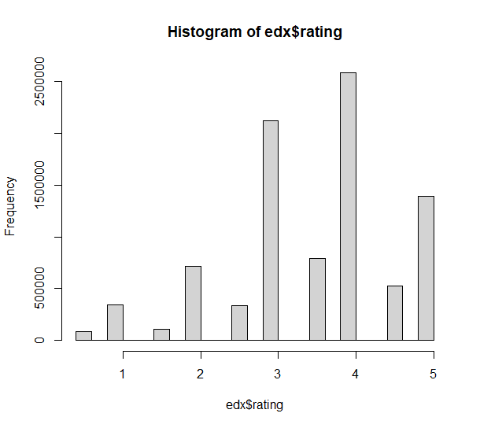

To help increase the accuracy of our modeling and the results of our recommendation engine, I opted to add some additional features to the data that might be leveraged by our algorithm. This included adding columns to the data to represent the component datetime pieces of the timestamp. I did this by first converting the epoch format datetime value to an easy to read (for a person) date time and also creating columns to represent the review year, month, day (as in the day of the month), weekday (Monday, Tuesday, etc), and hour of review. From our initial glance at the title field, we learned that the release year of the movie was in fact part of the title – for example movieId 122 = “Boomerang (1992)” was released in 1992. As with the components of the review datetime, I suspected that the year the movie was released might potentially impact the rating and decided to split this out as an additional feature. The following code was used to take the substring of the title which fell between the parenthesis and populate a new feature, year_extract with that information:

```r
   edx <- edx %>%
   mutate( year_extract =
        as.numeric(
             str_sub(
                  substrRight(title,5)
             , end = -2
                     )
                    )
                   )
```

Out of curiosity, I wanted to see that the oldest film in the dataset was. The following code revealed that “The Birth of a Nation”, released in 1915 was the oldest film in the edx dataset.

```r
   edx[which.min(edx$year_extract),] %>% select(title, rating, year_extract)
```

Once we had both the year of the film’s release and the review year, I considered that the age of the film (at the point of review) might be a factor. Like wine, some films would possibly age better than others and this could be an important feature for our recommendation system to leverage. To do this, another column was added to the dataset, the age_at_review feature, which simply took the review_year – year_extract. I did a few manual checks to confirm this worked correctly, which a visual inspection of this code and it’s results confirmed:

```r
   edx <- edx %>% mutate( age_at_review = edx$review_year - edx$year_extract)

   edx[1:10,] %>% select(title, year_extract, review_year, age_at_review)
```

I was curious what the “oldest” film was at the time of review, and unsurprisingly “The Birth of a Nation”, which we already established as the oldest film in our data received a review 93 years after release (notably received an above average rating of 4 compared to the full population’s naïve mean rating of 3.51)

```r
   edx[which.max(edx$age_at_review),] %>%
   select(title, rating, year_extract, review_year, age_at_review)
```

Now that we had done some additional data preparation and cleaning and enhanced our data will several features to support our recommendation engine, it was time to begin the process of developing our algorithm. First and foremost, the method for evaluating our model accuracy needed to be established. In this case, we will be using the typical error loss calculated via the residual mean squared error (RMSE). The RMSE is effectively the error we expect in our predicted movie rating and can be thought of like a standard deviation for the accuracy of our prediction. To facilitate testing, a function was created to easily evaluate the RMSE of our model using two vectors, the actual ratings from our data, and the predicted ratings from our algorithm.

```r
   RMSE <- function(true_ratings, predicted_ratings)
   {sqrt(mean((true_ratings – predicted_ratings)^2))}
```

To establish a baseline for our model accuracy, we can first take an average rating across the entire population. In the case of the edx dataset which we are using for training our model, this yields a result of 3.51. If we were to run this straight average through the loss function we get an RMSE of 1.06. This effectively tells us if we just assume everything has a rating of 3.5 (out of 5), we can expect our review to be off by about 1 star. This isn’t a very good model, so clearly we should work to build out a better algorithm for recommending movies!

```r
   mu <- mean(edx$rating)

   RMSE(validation$rating, mu)
   1.06
```

By modeling the effects of the different data features in our dataset we can allow our model to incorporate these into the predicted rating and reduce our RMSE. The way these effects were modeled is to essentially look at the mean ratings across groups of films with the same value of a given attribute, after subtracting the mean rating across the entire population and any other effects which may have already been modeled out. To begin, we will model the effect of a given movie first. In short, we know that some movies are better than others and in general would have a higher rating across all reviews for example. Isolating this impact from the overall population mean review and using it as a factor in our model will likely reduce our RMSE. To determine this movie effect, we will summarize the training population by movie (using movieId) and determine the mean score for each film less the population average. In other words, we will get a score that tells us how far from the population mean of 3.51 each film is rated (on average).

```r
   movie_avgs <- edx %>%
   group_by(movieId) %>%
   summarize(b_i = mean(rating – mu), mean_rating = mean(rating))
```

I also visualized the mean ratings of all our movies, and as shown below there were movies which clearly had mean review scores above and below the population average.

```r
plot(movie_avgs$movieId, movie_avgs$mean_rating)
```

##### Mean Rating by Movie

[figure not shown]

The next step was to incorporate each film’s score from this summary back into the original estimate that used just the population overall mean. The predicted rating for a movie became the population mean (mu) + the effect of that individual film’s overall ratings. The resulting impact in the model’s RMSE can be evaluated with the following code:

```r
   Predicted_ratings <- mu + validation %>%
   left_join(movie_avgs, by = ‘movieId’) %>%
   pull(b_i)

   RMSE(predicted_ratings, validation$rating)
```

This reduced our RMSE from 1.06 to .944, which was a considerable increase in model accuracy. We could do better though, and so we would next leverage additional features and continue to refine the model. The next step was to model and enhance the algorithm by including the effect of a given user. The explanation is that some folks will simply tend to score movies higher or lower than the population mean of 3.51. To model this effect, we will follow a similar pattern as we did for the user effect, but we will remove the existing factors of the population mean and the movie factor which was just determined.

```r
   User_avgs <- edx %>%
   left_join(movie_avgs, by = ‘movieId’) %>%
   group_by(userId) %>%
   summarize(b_u = mean(rating – mu – b_i), mean_rating = mean(rating))
```

We can observe this user bias by visualizing the mean rating by user. While we do see users consistently rate between 3 and 4, there are some users here who clearly rate on average above or below the population mean.